# TP2 Cancer de Prostate

# I) Analyse préliminaire des données de prostate

#### Question 1.a:

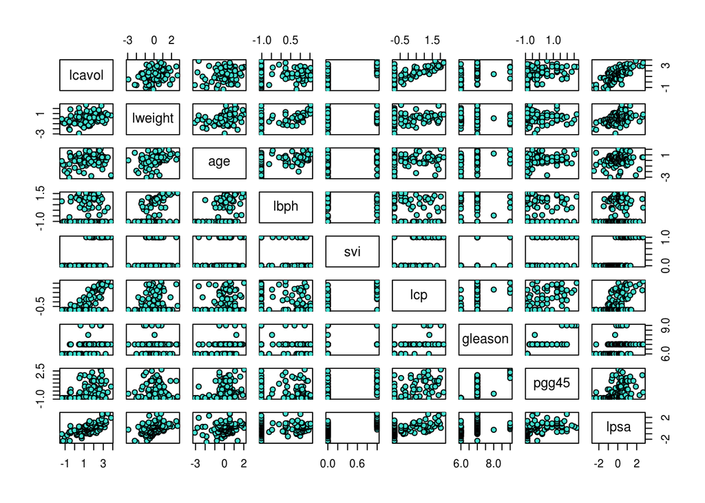

Si on visualise le graphe des correlations par pairs entre lcavol et les autres predicteurs, On peut remarquer que le nuage de points entre ($\textit{lcavol}$, $\textit{lpsa}$) et ($\textit{lcavol}$, $\textit{lcp}$) se regroupe autour d’une ligne, en soulignant un fort alignement pour le nuage de points ($\textit{lcavol}$, $\textit{lpsa}$). Pour la visualisation des autres nuages de points entre lcavol et les autres prédicteurs quantitatifs et qualitatifs, on peut pas déduire une information sur le degré de corrélation.

#### Question 1.b:

La visualisation par paires des corrélations permet d’avoir une idée sur la dépedance entre ($\textit{lcavol}$, $\textit{lpsa}$) et ($\textit{lcavol}$, $\textit{lcp}$), vu que ça suit une relation classique: dans ce cas une fonction affine. Cependant, on peut en déduire un idée sur la dépendance entre $\textit{lcavol}$ et les autres prédicteurs; C’est ce qui nous pousse à utiliser la commande R qui determine le coefficient de correlation entre deux grandeurs on obtient le tableau ci-dessous:

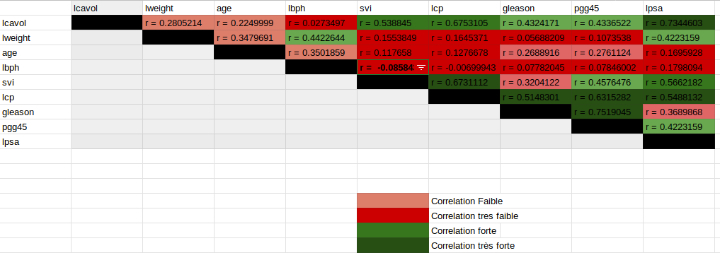

On peut remarquer que certains prédicteurs sont corrélés entre eux:

1)svi est corrélé à $\textit{lcavol}$ ; lcp est corrélé à $\textit{lcavol}$ ; $\textit{lcavol}$ est coréllé à $\textit{svi}$.

Ainsi $\textit{lcp}$ a un impact sur la dépendance entre $\textit{svi }$ et $\textit{lcavol}$ et aussi sur la dépendance entre $\textit{gleason }$ et $\textit{lcavol}$.

# II) Régression linéaire

#### a) Equation mathématique de la régression linéaire et explications du modèle:

Les deux variables $\textit{svi}$ et $\textit{gleason}$ sont considérées ci-dessous comme étant des variables qualitatifs. $\textit{svi}$ posséde deux niveaux de modalité et $\textit{gleason}$ posséde 4 niveaux de modalités. Le modéle initiale peut se mettre de cette manière:

$Y_i = \alpha_0 + \beta_1lweight_i + \beta_2age_i + \beta_3lbph_i + \beta_{40}\mathbb 1_{svi = 0} + \beta_{41}\mathbb 1_{svi = 1} + \beta_5lcp_i + \beta_{6}\mathbb 1_{gleason = 6} + \beta_{7}\mathbb 1_{gleason = 7}+ \beta_{8}\mathbb 1_{gleason = 8} + \beta_{9}\mathbb 1_{gleason = 9} + \beta_{10}pgg45_i + \varepsilon_i$

En faisant deux reparamétrisations faisant apparaître des effets différentiels par rapport à deux niveaux de référence successifs qu’est $<\textit{gleason} = 6>$ et $<\textit{svi} = 0>$ dans ce cas on obtient:

$Y_i = \beta_0 + \beta_1lweight_i + \beta_2age_i + \beta_3lbph_i + \beta_4\mathbb 1_{svi = 1} + \beta_5lcp_i + \beta_{7}\mathbb 1_{gleason = 7}+ \beta_{8}\mathbb 1_{gleason = 8} + \beta_{9}\mathbb 1_{gleason = 9} + \beta_{10}pgg45_i + \varepsilon_i$

Ainsi que les valeurs de $\textit{gleason7}$ et $\textit{gleason8}$ et $\textit{gleason9}$ sont relatifs au niveau de référence $<\textit{gleason} = 6>$ .

#### b) Summary:

```
##
## Call:
## lm(formula = lcavol ~ ., data = proC[, -1])
##
## Residuals:
##      Min       1Q   Median       3Q      Max
## -1.91436 -0.48444 -0.02664  0.54915  1.80062
##
## Coefficients:
##              Estimate Std. Error t value Pr(>|t|)
## (Intercept)  1.184390   0.171865   6.891 8.67e-10 ***
## lweight     -0.004818   0.090589  -0.053   0.9577
## age          0.184508   0.083691   2.205   0.0301 *
## lbph        -0.151173   0.084449  -1.790   0.0770 .
## svi1        -0.220419   0.256351  -0.860   0.3923
## lcp          0.563158   0.118954   4.734 8.58e-06 ***
## gleason7     0.311676   0.215268   1.448   0.1513
## gleason8    -0.710588   0.758827  -0.936   0.3517
## gleason9     0.790135   0.487510   1.621   0.1087
## pgg45       -0.266354   0.128039  -2.080   0.0405 *
## lpsa         0.634388   0.103997   6.100 2.94e-08 ***
## ---
## Signif. codes:  0 '***' 0.001 '**' 0.01 '*' 0.05 '.' 0.1 ' ' 1
##
## Residual standard error: 0.6973 on 86 degrees of freedom
## Multiple R-squared:  0.6865, Adjusted R-squared:   0.65
## F-statistic: 18.83 on 10 and 86 DF,  p-value: < 2.2e-16
```

#### c) Elimination de lcp et lpsa du modèle de regression:

En eliminant $\textit{lcp}$ et $\textit{lpsa}$ de notre modèle de regression on remarque que la quasi-totalité de l’information de $\textit{lcavol}$ sera dans $\textit{svi}$ et $\textit{gleason}$ , ce qui raisonable car dans la partie 1) on a souligné la forte corrélation entre $\textit{lcp}$ et $\textit{svi}$ et $\textit{svi}$ et $\textit{lpsa}$ d’une part et entre $\textit{lcp}$ et $\textit{gleason}$ d’autre part. Ce transfert d’information est dû à la forte correlation de $\textit{lcavol}$ avec $\textit{lpsa}$ et $\textit{lcp}$ .

Ceci confirmé en simulant ce nouvau modèle: on obtient une $p-value = 0.000291$ pour $\textit{svi}$.

De plus le coefficient de corrélation de ce nouveau modèle a diminué de 0.6865 à 0.4327, Le modèle est moins cohérent que le premier, Ce qui est logique car $\textit{lpsa}$ et $\textit{lcp}$ sont les plus corréllées à $\textit{lcavol}$.

```
##
## Call:
## lm(formula = lcavol ~ proC$svi + proC$gleason + lweight + age +
##     lbph + pgg45, data = proC[, -1])
##
## Residuals:
##      Min       1Q   Median       3Q      Max
## -1.84488 -0.48256 -0.01752  0.58918  2.21990
##
## Coefficients:
##               Estimate Std. Error t value Pr(>|t|)
## (Intercept)    0.59838    0.20857   2.869 0.005155 **
## proC$svi1      1.02458    0.27147   3.774 0.000291 ***
## proC$gleason7  0.80074    0.27443   2.918 0.004473 **
## proC$gleason8  0.68687    0.96012   0.715 0.476253
## proC$gleason9  1.17265    0.64444   1.820 0.072214 .
## lweight        0.25060    0.11102   2.257 0.026472 *
## age            0.05424    0.10924   0.497 0.620739
## lbph          -0.10829    0.11197  -0.967 0.336097
## pgg45         -0.01216    0.15899  -0.076 0.939203
## ---
## Signif. codes:  0 '***' 0.001 '**' 0.01 '*' 0.05 '.' 0.1 ' ' 1
##
## Residual standard error: 0.9272 on 88 degrees of freedom
## Multiple R-squared:  0.4327, Adjusted R-squared:  0.3811
## F-statistic:  8.39 on 8 and 88 DF,  p-value: 2.11e-08
```

#### d) Impact de lcp sur le modèle de la question1:

En utilisant R On obtient: $[0.3266853, 0.7996307]$: On remarque que 0 n’appartient pas à l’intervalle de confiance. et donc On peut rejetter l’hypothèse nulle qu’est $\beta = 0$.

Conclusion: On obtient une $p-value = 8.58e-06$ pour $\textit{lcp}$ qui est très faible, ce qui soutenu par l’intervalle de confiance étroit.

#### e) Distribution de la statistique t et cohérence des variables indiquées *:

Sous l’hypothèse nulle: La distribution de la probabilité de t est celle de la distribution de la loi de student. Le paramètre de la loi de student est égale à $n -p - 1 = 97 -10 -1 = 86$. Avec: $n$ = nombre d’obsevations, $p$ = nombre de variables. La valeur de t pour laquel $P = 0.05$ est égale à ${F_{st(86)} }^{-1}(1-0.05/2)$ = 1.987608 ou -1.987608 La variable $\textit{age}$ est notée $*$, Ce qui est cohérent car sa $|t-value| = |2.205| = 2.205 > |t| = 1.987608$.

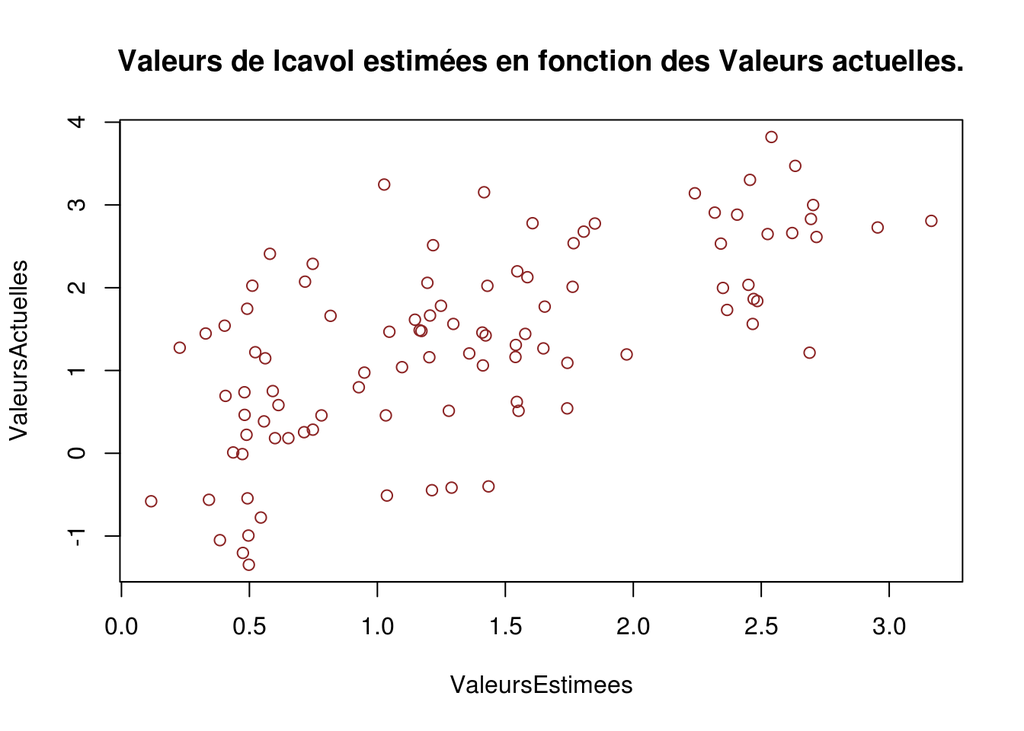

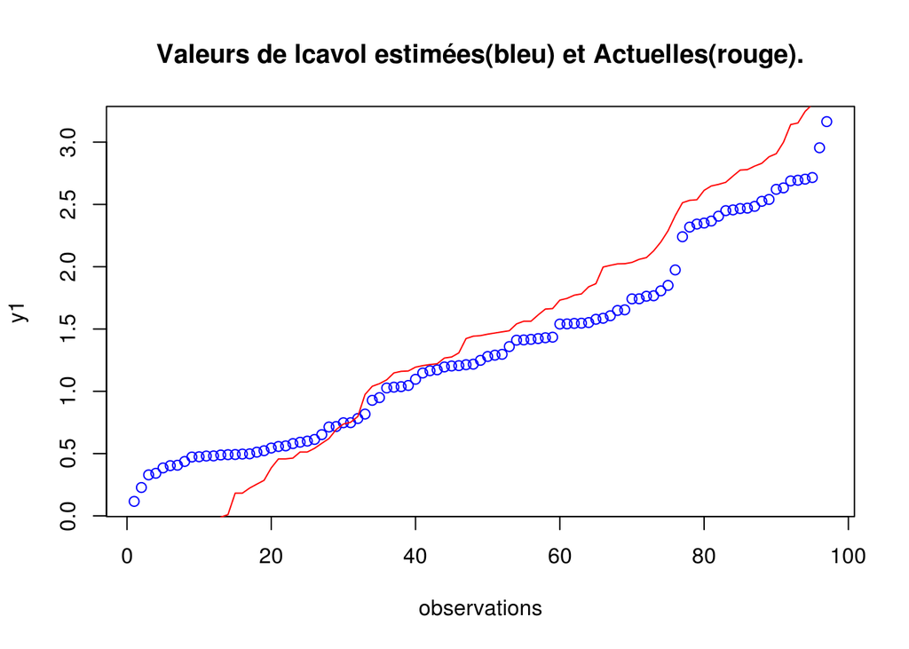

L’allure de la densité des résidus converge vers une densité d’une gaussienne, voire la figure de l’histogramme des résidus.

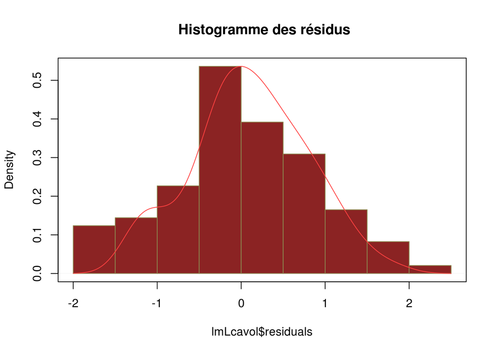

La valeur RSS vaut: 41.81407

# III) Effet des prédicteurs qualitatifs:

On peut affirmer à l’aide de ANOVA que Les deux prédicteurs qualitatifs: $\textit{svi}$ et $\textit{gleason}$ ont un effet important sur l’information de lcavol , vu que leurs p-value sont faibles : $2.23e-09$ pour $\textit{svi}$ et $0.00233$ pour $\textit{gleason}$.

```
## Tables of means
## Grand mean
##
## 1.35001
##
##  factor(svi)
##          0      1
##      1.018  2.552
## rep 76.000 21.000
##
##  factor(gleason)
##           6      7     8     9
##      0.8971  1.582 1.755 1.847
## rep 35.0000 56.000 1.000 5.000
##
##  factor(svi):factor(gleason)
##            factor(gleason)
## factor(svi) 6     7     8     9
##         0    0.56  1.35  1.42  2.02
##         rep 35.00 37.00  1.00  3.00
##         1          2.58        2.28
##         rep  0.00 19.00  0.00  2.00
```

```
##                             Df Sum Sq Mean Sq F value   Pr(>F)
## factor(svi)                  1  38.72   38.72  44.091 2.23e-09 ***
## factor(gleason)              3  13.69    4.56   5.198  0.00233 **
## factor(svi):factor(gleason)  1   1.03    1.03   1.168  0.28270
## Residuals                   91  79.92    0.88
## ---
## Signif. codes:  0 '***' 0.001 '**' 0.01 '*' 0.05 '.' 0.1 ' ' 1
```

# IV) Best Subset Selection:

#### a) la non-optimalité de la partie 2:

La partie 2 n’est pas optimale parce qu’elle ne prend pas en considération les différentes combinaisons possibles entre les prédicteurs. $lm(lcavol~1,data=pro)$ est une regression de taille 0. $lm(lcavol~.,data=pro[,c(1,4,9)])$ est une regression linéaire de tous le prédicteurs par rapport aux variables 1,4 et 9.

$lm(lcavol~.,data=pro[,c(1,2,9)])$ est une regression linéaire de tous le prédicteurs par rapport aux variables 1,2 et 9.

Pour calculer RSS on utilise la formule $rss = sum(lmLcavol$residuals^2)$.

#### b) Fonction minimsant RSS pour chaque k:

```
## [1] "lpsa"
```

```
## [1] "lcp"  "lpsa"
```

```
## [1] "age"  "lcp"  "lpsa"
```

```
## [1] "age"  "lbph" "lcp"  "lpsa"
```

```
## [1] "age"     "lcp"     "gleason" "pgg45"   "lpsa"
```

```
## [1] "age"     "lbph"    "lcp"     "gleason" "pgg45"   "lpsa"
```

```
## [1] "age"     "lbph"    "svi"     "lcp"     "gleason" "pgg45"   "lpsa"
```

```
## [1] "lweight" "age"     "lbph"    "svi"     "lcp"     "gleason" "pgg45"
## [8] "lpsa"
```

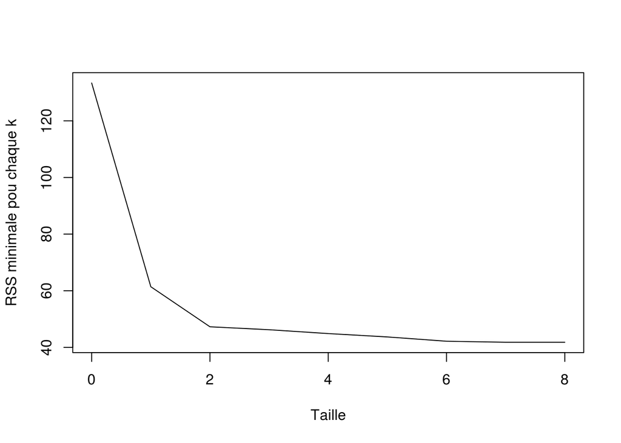

### c) Ce modèle n’est pas optimal:

Si cette méthode est efficace pour prédire le modèle optimale alors on choisira toujours le modèle de taille maximale puisque RSS diminue en augmentant le nombre de prédicteurs.

# V) Split-validation:

#### a) Définition de split-validation:

La Split-validation est une approche standard pour estimer l’erreur de prédiction en consistant à diviser le jeu de données en deux parties:Apprentissage avec n1 individus et Validation avec n2 individus.

-L’ensemble d’Apprentissage est utilisé pour s’adapter aux modèles, c’est-à-dire pour fournir des estimations des coefficients de régression.$(\hat\beta_0, \hat\beta_1, ...,\hat\beta_p)$

-Le jeu de validation est utilisé pour estimer l’erreur de prédiction.L’erreur de prédiction est donné par la formule:

$E_{pred} = \frac{ 1 }{ n_2 }\sum\limits_{(x_i,y_i)\in Validation ~ Set}\left( y_i - \left(\widehat{\beta}_0 + \sum_{j=1}^px_{ ij }\widehat{ \beta}_j\right)\right)^2$

Nous choisissons généralement le modèle qui génère la plus petite erreur de prédiction.

#### b)

```
##
## Call:
## lm(formula = lcavol ~ ., data = proC[-valid, c(1, 6, 9)])
##
## Residuals:
##      Min       1Q   Median       3Q      Max
## -1.11959 -0.57345 -0.08939  0.62260  1.97063
##
## Coefficients:
##             Estimate Std. Error t value Pr(>|t|)
## (Intercept)  1.34633    0.08631  15.598  < 2e-16 ***
## lcp          0.34727    0.10450   3.323   0.0015 **
## lpsa         0.69561    0.10722   6.488 1.64e-08 ***
## ---
## Signif. codes:  0 '***' 0.001 '**' 0.01 '*' 0.05 '.' 0.1 ' ' 1
##
## Residual standard error: 0.6957 on 62 degrees of freedom
## Multiple R-squared:  0.6682, Adjusted R-squared:  0.6575
## F-statistic: 62.43 on 2 and 62 DF,  p-value: 1.405e-15
```

L’erreur d’apprentissage est donné par la cette commande $R$ :

```r
Ertraining <- sum(lmSplit$residuals**2)/32
```

#### c) L’ereur de prédiction:

Pour calculer l’erreur de prédiction on utilise la formule :

$E_{pred} = \frac{ 1 }{ n_2 }\sum\limits_{(x_i,y_i)\in Validation ~ Set}\left( y_i - \left(\widehat{\beta}_0 + \sum_{j=1}^px_{ ij }\widehat{ \beta}_j\right)\right)^2$

#### d) Les 9 differents modèles:

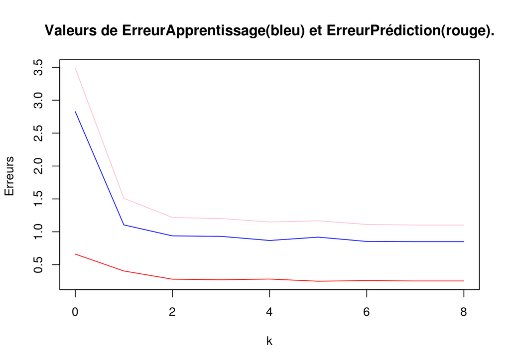

#### Question e):

Le principal problème de la split-Validation est la multitude de choix pour choisir la valeur de n1 et n2 pour en déduire le modèle optimale. Du coup on peut tomber sur un modèle plus précis en modifiant n1 et n2.

#### Question f):

On peut éventuellement penser à la méthode de cross-validation.